# Tidying & Visualizing Data

## 3.1 Aesthetic Mapping

The basic idea is that we want to take our data and *map* it onto physical space using geometric objects or geoms. For ggplot to place a geom, it needs to know how the data map onto the aesthetics of the graph. Each `geom()` function in ggplot takes a `mapping` argument. Let’s start with a basic geom, `geom_histogram()`.

### 3.1.1 Mapping with geoms

We’re going to call ggplot()`again, and this time add the`geom_histogram()`*layer*, telling it to map the variable`Sepal.Length` to the x axis aesthetic:

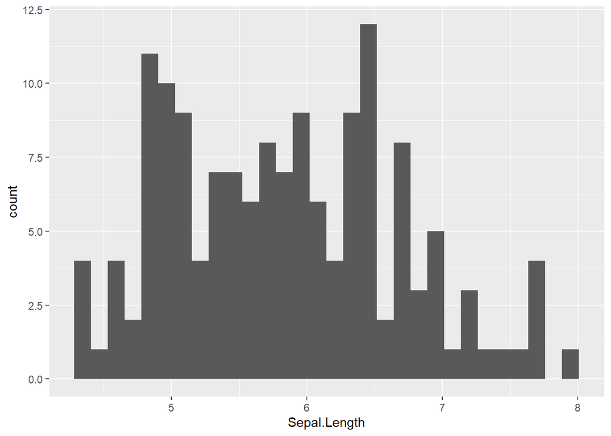

```r
ggplot(data = iris) + # attach data
    geom_histogram(mapping = aes(x = Sepal.Length)) # add geom w/ aesthetic map
```

`geom_histogram()` only requires one *aesthetic mapping*, the x aesthetic, which tells it what variable it should map to the x axis. You can add additional arguments to the `geom()`. For example, we could change the number of bins:

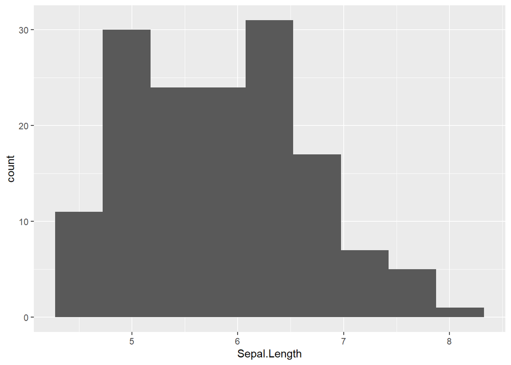

```r
ggplot(data = iris) + # attach data
    geom_histogram(mapping = aes(x = Sepal.Length), # add geom to aesthetic mapping
                   bins = 9) # change bins to 9
```

Or make them a different color. We can change the color of 2-d objects with the fill aesthetic:

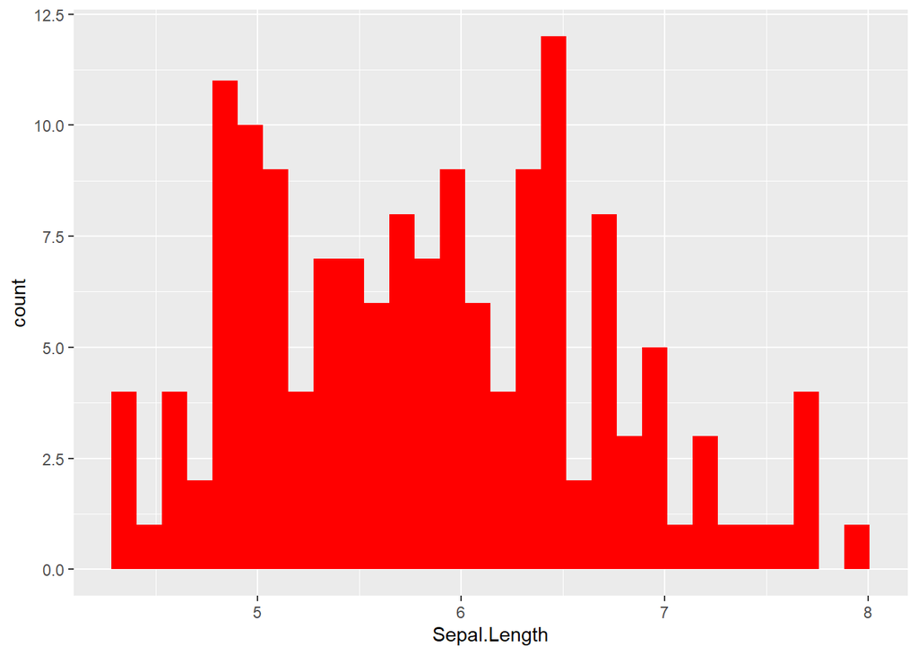

```r
ggplot(data = iris) + # attach data
    geom_histogram(mapping = aes(x = Sepal.Length),
                   fill = "red") # fill, bc hist bars are 2-d
```

Let’s look at something just a tiny but more complicated: we’ll add a layer of points to our plot (creating a scatterplot) using geom_point(). geom_point() is another *geom function*, each of which adds a different type of layer to a plot. Let’s see what happens if we just give it an x variable to map:

```r
ggplot(data = iris) + # attach data
    geom_point(mapping = aes(x = Sepal.Length)) # add geom w/ aesthetic map
```

[output not shown]

We get an error, telling us that `geom_point` requires the y aesthetic to be defined. This makes sense - we need an x and y axis to define where points belong on a scatter plot. Let’s add `Petal.Length` as the y axis:

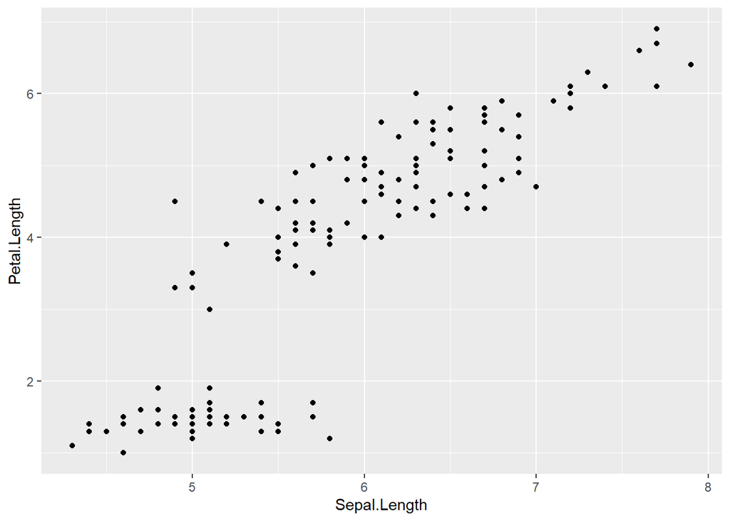

```r
ggplot(data = iris) + # attach data
    geom_point(mapping = aes(x = Sepal.Length, y = Petal.Length)) # add geom w/ aesthetic map
```

Let’s find out if the relationship between `Sepal.Length` & `Petal.Length` relates to the `Species` of iris. To visualize this, we are going to map `Species` to an *aesthetic* too. We’ll use the color aesthetic, which is like fill but for 1-d objects (e.g., points, lines, etc.).

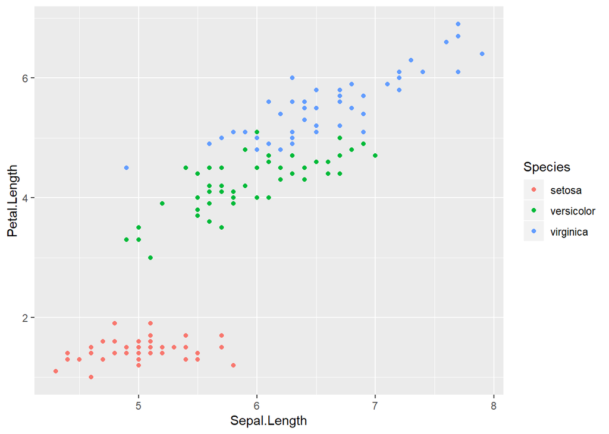

```r
ggplot(data = iris) + # attach data
  geom_point(mapping = aes(x = Sepal.Length, # geom w/ aesthetic mapping
                           y = Petal.Length,
                           color = Species)) # color including in aes()
```

Notice that we included color in our aesthetic mapping call (`mapping = aes()`) here, but not when we filled our histogram with the color red. This is the difference between aesthetically mapping data and just setting an aesthetic to some value (e.g., “red”).

This is a fairly common mistake, so let’s take a look at what happens if we tell it to make our points red but accidentally include that in the `aes()` call:

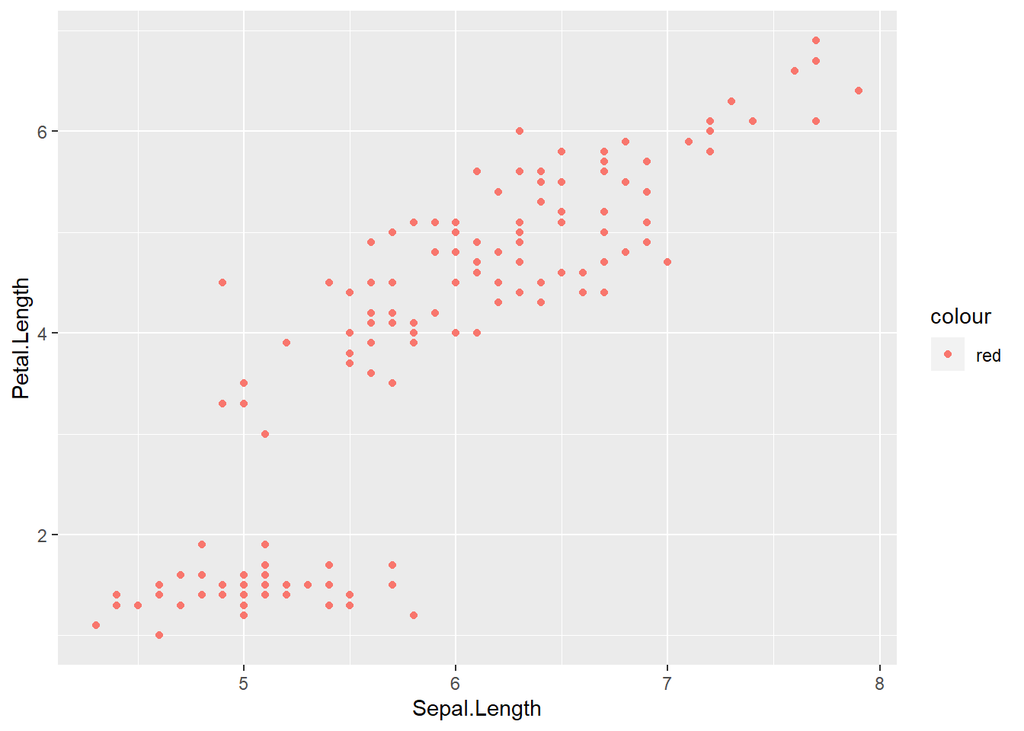

```r
ggplot(data = iris) + # attach data
  geom_point(mapping = aes(x = Sepal.Length, # geom w/ aesthetic mapping
                           y = Petal.Length,
                           color = "red")) # color including in aes()
```